# DLBCL Prognostic Gene Signatures

Genome-Wide Survival Analysis by Cell of Origin

HMRN/Lacy Cohort Analysis

2026-01-19

# 1 Executive Summary

This analysis identifies **prognostic gene signatures** in Diffuse Large B-Cell Lymphoma (DLBCL) through unbiased genome-wide survival analysis across Cell of Origin (COO) subtypes.

# 2 Methodology

## 2.1 Study Cohort

COO Distribution in HMRN/Lacy Cohort

| COO Subtype | N | Percentage |
| --- | --- | --- |
| ABC | 345 | 26.5 |
| GCB | 517 | 39.7 |
| MHG | 164 | 12.6 |
| UNC | 277 | 21.3 |

**Data Source**: HMRN/Lacy Cohort (GSE181063)

- **Platform**: Illumina HumanHT-12 V4 BeadChip (GPL14951)
- **Probes**: 29,372 expression probes
- **Samples**: 1303 with survival data
- **Endpoint**: Overall Survival (OS)

## 2.2 Statistical Analysis

### 2.2.1 Univariate Survival Analysis

For each probe $i$ and sample $j$:

$$h(t|x_{ij}) = h_0(t) \cdot \exp(\beta_i
\cdot x_{ij})$$

Where:

- $h(t)$ = hazard at time $t$
- $h_0(t)$ = baseline hazard
- $x_{ij}$ = standardized expression (z-score)
- $\beta_i$ = log hazard ratio

**Multiple Testing Correction**: Benjamini-Hochberg FDR

### 2.2.2 IPI-Adjusted Analysis (Multivariate)

$$h(t|x, IPI) = h_0(t) \cdot
\exp(\beta_{gene} \cdot x + \beta_{IPI} \cdot IPI)$$

Genes with $p_{adjusted} < 0.05$ are considered **IPI-independent**.

# 3 Results by COO Subset

## 3.1 Global Analysis (All COO)

Global Survival Analysis Summary (n=1,303)

| Metric | Value |
| --- | --- |
| Total probes tested | 29,349 |
| Significant (p < 0.05) | 10,402 |
| Significant (FDR < 0.05) | 6,748 |
| Protective (HR < 1, FDR < 0.05) | 2,713 |
| Adverse (HR > 1, FDR < 0.05) | 4,035 |

### 3.1.1 Kaplan-Meier: Global Signature Score

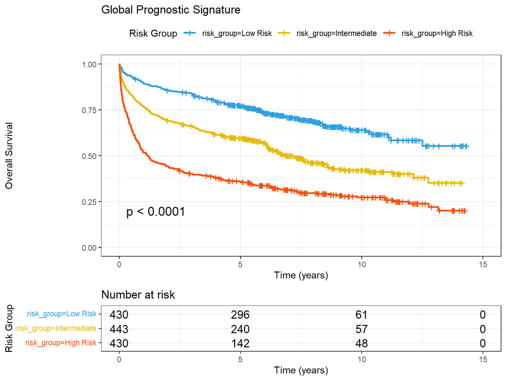

Survival by Global Prognostic Signature Score

### 3.1.2 Top Protective Genes (Global)

Top 20 Protective Genes (HR < 1) - Global Analysis

| Gene | Probe | HR | 95% CI | P-value | FDR |
| --- | --- | --- | --- | --- | --- |
| SIRPG | ILMN_2383058 | 0.796 | (0.758-0.836) | 1.44e-19 | 4.23e-15 |
| SIRPG | ILMN_1771801 | 0.794 | (0.754-0.835) | 4.19e-19 | 6.15e-15 |
| MMP9 | ILMN_1796316 | 0.761 | (0.713-0.813) | 3.56e-16 | 2.61e-12 |
| CD3D | ILMN_2261416 | 0.825 | (0.788-0.864) | 5.45e-16 | 2.70e-12 |
| CD3E | ILMN_1739794 | 0.776 | (0.73-0.825) | 5.53e-16 | 2.70e-12 |
| CD1E | ILMN_2335754 | 0.736 | (0.684-0.793) | 7.83e-16 | 3.25e-12 |
| BCL11B | ILMN_1665761 | 0.813 | (0.773-0.855) | 9.40e-16 | 3.25e-12 |
| PRKCH | ILMN_1780898 | 0.701 | (0.643-0.765) | 9.97e-16 | 3.25e-12 |
| LST1 | ILMN_2345353 | 0.699 | (0.64-0.764) | 2.07e-15 | 5.97e-12 |
| CD6 | ILMN_1746565 | 0.822 | (0.783-0.863) | 2.40e-15 | 5.97e-12 |
| LCP2 | ILMN_1658962 | 0.693 | (0.632-0.758) | 2.44e-15 | 5.97e-12 |
| LST1 | ILMN_1688373 | 0.638 | (0.571-0.713) | 2.69e-15 | 6.07e-12 |
| TCF7 | ILMN_1676470 | 0.806 | (0.763-0.85) | 3.06e-15 | 6.40e-12 |
| LCK | ILMN_2377109 | 0.767 | (0.717-0.819) | 3.27e-15 | 6.40e-12 |
| SH2D1A | ILMN_1705892 | 0.761 | (0.71-0.817) | 2.17e-14 | 3.99e-11 |
| JAML | ILMN_1778723 | 0.779 | (0.73-0.831) | 4.58e-14 | 7.47e-11 |
| FNDC1 | ILMN_1734653 | 0.829 | (0.789-0.871) | 1.30e-13 | 1.91e-10 |
| PDLIM3 | ILMN_2230025 | 0.791 | (0.743-0.842) | 1.42e-13 | 1.95e-10 |
| CSF2RA | ILMN_2376455 | 0.777 | (0.726-0.83) | 1.58e-13 | 1.98e-10 |
| ABLIM1 | ILMN_1785424 | 0.770 | (0.718-0.825) | 1.62e-13 | 1.98e-10 |

### 3.1.3 Top Adverse Genes (Global)

Top 20 Adverse Genes (HR > 1) - Global Analysis

| Gene | Probe | HR | 95% CI | P-value | FDR |
| --- | --- | --- | --- | --- | --- |
| POLR3G | ILMN_2070349 | 1.329 | (1.242-1.421) | 1.09e-16 | 1.07e-12 |
| EXO1 | ILMN_1719089 | 1.366 | (1.26-1.482) | 4.25e-14 | 7.34e-11 |
| C19orf48 | ILMN_1681124 | 1.287 | (1.205-1.374) | 5.82e-14 | 8.99e-11 |
| UBE2Q2P2 | ILMN_3235825 | 1.333 | (1.235-1.439) | 1.46e-13 | 1.95e-10 |
| EXO1 | ILMN_2351916 | 1.327 | (1.228-1.435) | 1.07e-12 | 1.01e-09 |
| POLR1G | ILMN_1747870 | 1.421 | (1.288-1.567) | 2.11e-12 | 1.63e-09 |
| EME1 | ILMN_1750102 | 1.433 | (1.296-1.584) | 2.21e-12 | 1.67e-09 |
| UBE2V2 | ILMN_2076567 | 1.590 | (1.396-1.811) | 3.10e-12 | 2.22e-09 |
| TMEM97 | ILMN_1710962 | 1.525 | (1.353-1.72) | 5.49e-12 | 3.50e-09 |
| PCLAF | ILMN_1732150 | 1.288 | (1.198-1.384) | 5.91e-12 | 3.69e-09 |
| SNORA71C | ILMN_3240216 | 1.464 | (1.313-1.633) | 7.34e-12 | 4.34e-09 |
| MACIR | ILMN_1677292 | 1.427 | (1.289-1.58) | 7.39e-12 | 4.34e-09 |
| GTPBP3 | ILMN_1777156 | 1.582 | (1.384-1.807) | 1.56e-11 | 7.89e-09 |
| DNA2 | ILMN_2282959 | 1.401 | (1.269-1.547) | 2.74e-11 | 1.30e-08 |
| SLC19A1 | ILMN_1698996 | 1.282 | (1.192-1.38) | 2.91e-11 | 1.34e-08 |
| E2F7 | ILMN_1798210 | 1.269 | (1.182-1.363) | 6.29e-11 | 2.51e-08 |
| KIF23 | ILMN_1716553 | 1.338 | (1.225-1.462) | 9.01e-11 | 3.33e-08 |
| FAM72B | ILMN_3243986 | 1.356 | (1.236-1.486) | 9.09e-11 | 3.33e-08 |
| EHHADH | ILMN_1701507 | 1.253 | (1.17-1.341) | 9.82e-11 | 3.47e-08 |
| ECE2 | ILMN_1762883 | 1.515 | (1.335-1.72) | 1.23e-10 | 4.10e-08 |

## 3.2 GCB Subset Analysis (n=517)

GCB Subset Survival Analysis Summary

| Metric | Value |
| --- | --- |
| Total probes tested | 29,357 |
| Significant (FDR < 0.05) | 909 |
| Protective | 392 |
| Adverse | 517 |

### 3.2.1 Kaplan-Meier: GCB Signature

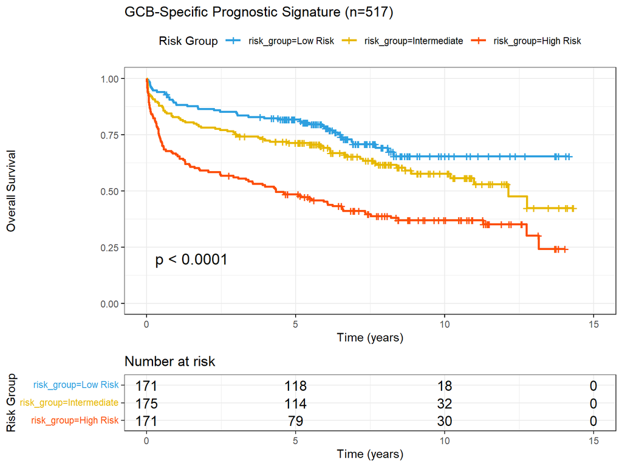

Survival by GCB-Specific Prognostic Signature

### 3.2.2 Top GCB-Specific Genes

Top 15 GCB-Specific Prognostic Genes

| Gene | HR | Direction | P-value |
| --- | --- | --- | --- |
| CD3D | 0.569 | Protective | 6.38e-08 |
| TIGIT | 0.676 | Protective | 1.01e-07 |
| QPCTL | 1.353 | Adverse | 3.57e-07 |
| PRND | 0.808 | Protective | 4.40e-07 |
| CD3E | 0.734 | Protective | 4.74e-07 |
| CD1E | 0.718 | Protective | 5.13e-07 |
| PHRF1 | 1.477 | Adverse | 5.59e-07 |
| ZNF792 | 0.741 | Protective | 5.85e-07 |
| FHIT | 0.727 | Protective | 6.11e-07 |
| PKMYT1 | 1.273 | Adverse | 9.51e-07 |
| NME2 | 1.473 | Adverse | 9.84e-07 |
| KIF23 | 1.543 | Adverse | 1.00e-06 |
| SIRPG | 0.789 | Protective | 1.39e-06 |
| MAL | 0.793 | Protective | 1.40e-06 |
| CD3D | 0.779 | Protective | 1.45e-06 |

## 3.3 ABC Subset Analysis (n=345)

ABC Subset Survival Analysis Summary

| Metric | Value |
| --- | --- |
| Total probes tested | 29,361 |
| Significant (FDR < 0.05) | 967 |
| Protective | 374 |
| Adverse | 593 |

### 3.3.1 Kaplan-Meier: ABC Signature

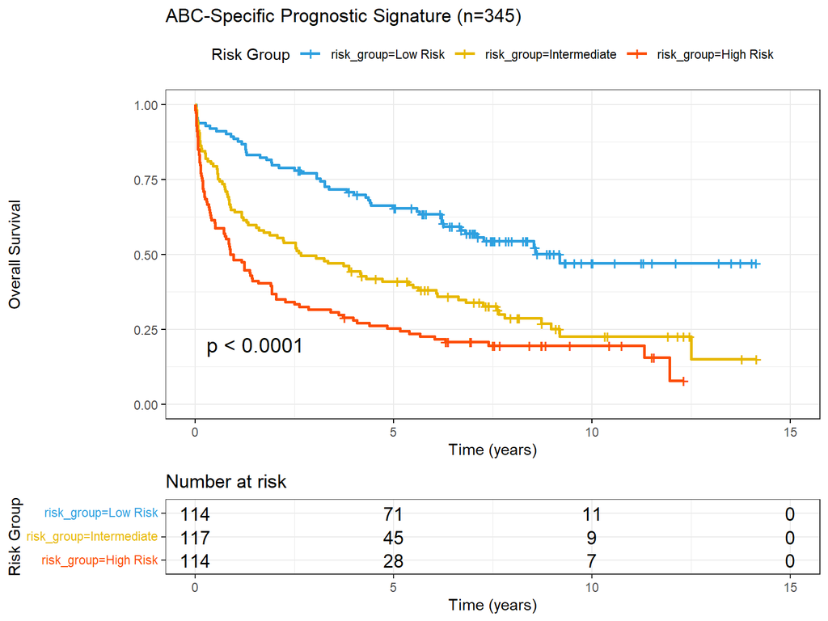

Survival by ABC-Specific Prognostic Signature

## 3.4 MHG Subset Analysis (n=164)

MHG Subset Survival Analysis Summary

| Metric | Value |
| --- | --- |
| Total probes tested | 29,361 |
| Significant (FDR < 0.05) | 21 |
| Significant (p < 0.05) | 2,792 |

*Note: MHG subset shows limited significant genes due to smaller sample size and inherently poor prognosis.*

## 3.5 UNC Subset Analysis (n=277)

UNC Subset Survival Analysis Summary

| Metric | Value |
| --- | --- |
| Total probes tested | 29,362 |
| Significant (FDR < 0.05) | 373 |
| Protective | 195 |
| Adverse | 178 |

# 4 Pathway Enrichment Analysis (GSEA)

## 4.1 Methods

Gene Set Enrichment Analysis was performed using **enrichR** with the following databases:

- KEGG 2021 Human
- GO Biological Process 2023
- Reactome 2022
- MSigDB Hallmark 2020
- BioPlanet 2019

## 4.2 Global Protective Pathways

Top Protective Pathways (Good Prognosis)

| Database | Pathway | Overlap | Adj. P-value |
| --- | --- | --- | --- |
| KEGG | T cell receptor signaling pathway | 16/104 | 4.06e-12 |
| MSigDB Hallmark | Allograft Rejection | 19/200 | 2.37e-11 |
| KEGG | Primary immunodeficiency | 9/38 | 1.84e-08 |
| KEGG | Hematopoietic cell lineage | 12/99 | 4.43e-08 |
| KEGG | Th1 and Th2 cell differentiation | 10/92 | 2.56e-06 |
| MSigDB Hallmark | IL-2/STAT5 Signaling | 13/199 | 4.95e-06 |
| KEGG | Cell adhesion molecules | 10/148 | 1.57e-04 |
| KEGG | PD-L1 expression and PD-1 checkpoint pathway in cancer | 8/89 | 1.57e-04 |
| KEGG | Th17 cell differentiation | 8/107 | 5.26e-04 |
| MSigDB Hallmark | Epithelial Mesenchymal Transition | 10/200 | 8.03e-04 |
| KEGG | Yersinia infection | 8/137 | 2.67e-03 |
| KEGG | Cytokine-cytokine receptor interaction | 11/295 | 7.40e-03 |
| MSigDB Hallmark | Complement | 8/200 | 1.38e-02 |
| MSigDB Hallmark | Coagulation | 6/138 | 2.80e-02 |
| MSigDB Hallmark | Apical Junction | 7/200 | 3.15e-02 |

**Key Protective Pathways:**

- **Allograft Rejection** (p = 2.4e-11): T-cell mediated immunity
- **IL-2/STAT5 Signaling** (p = 4.9e-06): T-cell activation
- **T-cell Receptor Signaling**: Immune surveillance

## 4.3 Global Adverse Pathways

Top Adverse Pathways (Poor Prognosis)

| Database | Pathway | Overlap | Adj. P-value |
| --- | --- | --- | --- |
| MSigDB Hallmark | E2F Targets | 20/200 | 8.73e-12 |
| MSigDB Hallmark | G2-M Checkpoint | 15/200 | 2.46e-07 |
| MSigDB Hallmark | Myc Targets V1 | 14/200 | 1.19e-06 |
| KEGG | Cell cycle | 10/124 | 2.90e-04 |
| KEGG | DNA replication | 6/36 | 2.90e-04 |
| KEGG | Mismatch repair | 5/23 | 3.29e-04 |
| MSigDB Hallmark | Myc Targets V2 | 6/58 | 4.98e-04 |
| KEGG | RNA transport | 10/186 | 2.92e-03 |
| KEGG | Homologous recombination | 5/41 | 3.71e-03 |
| KEGG | One carbon pool by folate | 3/20 | 4.30e-02 |
| KEGG | Nucleotide excision repair | 4/47 | 5.21e-02 |
| KEGG | Vitamin digestion and absorption | 3/24 | 5.54e-02 |
| MSigDB Hallmark | mTORC1 Signaling | 7/200 | 6.14e-02 |
| MSigDB Hallmark | UV Response Up | 6/158 | 6.14e-02 |
| KEGG | Pyrimidine metabolism | 4/56 | 7.69e-02 |

**Key Adverse Pathways:**

- **E2F Targets**: Cell cycle progression
- **G2M Checkpoint**: Proliferation
- **DNA Repair / Homologous Recombination**: Genomic instability
- **MYC Targets**: Oncogenic signaling

## 4.4 Pathway Summary by COO Subset

Pathway Enrichment Summary by COO Subset

| Subset | Top Protective | Top Adverse |
| --- | --- | --- |
| Global | Allograft Rejection, IL-2/STAT5 | E2F Targets, Cell Cycle |
| GCB | T helper molecules, Apoptosis | E2F/MYC Targets |
| ABC | RNA metabolism | E2F/MYC Targets, DNA Repair |
| MHG | Limited enrichment | Cell cycle (nominal) |
| UNC | TCR signaling, CD8+ T cells | E2F Targets |

# 5 IPI-Independent Analysis (GCB Subset)

## 5.1 Rationale

The **International Prognostic Index (IPI)** is the standard clinical risk score for DLBCL. We tested whether gene expression signatures provide prognostic information **independent of IPI**.

## 5.2 Methodology

**Analysis Design:**

1. **Cohort**: 317 GCB samples with complete IPI data
2. **Model Comparison**:
   - **Univariate**: Gene expression only
   - **Multivariate**: Gene expression + IPI score
3. **Significance**: Genes with adjusted p < 0.05 in multivariate model

## 5.3 IPI-Independence Results

IPI Independence Analysis Summary

| Metric | Value |
| --- | --- |
| Samples with IPI data | 317 |
| Univariate significant (p < 0.05) | 3,037 |
| IPI-adjusted significant (p < 0.05) | 2,839 |
| Remain significant after IPI adjustment | 2,311 |
| Lose significance after IPI adjustment | 726 |
| Gain significance after IPI adjustment | 528 |

## 5.4 Kaplan-Meier: IPI-Independent Signature

[figure not shown]

## 5.5 Top IPI-Independent Genes

### 5.5.1 Protective (IPI-Independent)

Top IPI-Independent Protective Genes

| Gene | Univariate HR | Adjusted HR | Uni P | Adj P | IPI P |
| --- | --- | --- | --- | --- | --- |
| ZZZ3 | 0.569 | 0.552 | 4.87e-07 | 2.22e-07 | 1.46e-07 |
| PRND | 0.777 | 0.773 | 1.43e-06 | 9.93e-07 | 1.78e-07 |
| TRMO | 0.682 | 0.666 | 2.60e-05 | 1.01e-05 | 1.08e-07 |
| LGALS8 | 0.725 | 0.710 | 5.48e-05 | 2.41e-05 | 1.43e-07 |
| ZNF792 | 0.760 | 0.741 | 9.03e-05 | 3.21e-05 | 1.08e-07 |
| MAL | 0.761 | 0.796 | 2.24e-06 | 7.61e-05 | 3.65e-05 |
| ZNF680 | 0.733 | 0.716 | 1.90e-04 | 7.80e-05 | 1.17e-07 |
| CD1E | 0.711 | 0.733 | 1.65e-05 | 9.44e-05 | 4.78e-06 |
| ISCA1 | 0.747 | 0.713 | 6.15e-04 | 1.17e-04 | 4.18e-08 |
| ARHGEF6 | 0.662 | 0.651 | 1.51e-04 | 1.21e-04 | 2.23e-07 |
| MYNN | 0.696 | 0.670 | 4.30e-04 | 1.24e-04 | 8.98e-08 |
| BBOF1 | 0.720 | 0.689 | 5.33e-04 | 1.27e-04 | 5.79e-08 |
| PALD1 | 0.655 | 0.638 | 3.46e-04 | 1.41e-04 | 9.22e-08 |
| YIPF3 | 0.536 | 0.519 | 2.47e-04 | 1.64e-04 | 1.94e-07 |
| TNFRSF17 | 0.812 | 0.816 | 1.46e-04 | 1.86e-04 | 4.06e-07 |

### 5.5.2 Adverse (IPI-Independent)

Top IPI-Independent Adverse Genes

| Gene | Univariate HR | Adjusted HR | Uni P | Adj P | IPI P |
| --- | --- | --- | --- | --- | --- |
| PPCDC | 1.439 | 1.434 | 1.99e-07 | 3.05e-07 | 5.56e-07 |
| CSTPP1 | 1.697 | 1.674 | 4.97e-07 | 1.73e-06 | 1.29e-06 |
| NOMO1 | 1.915 | 2.110 | 4.07e-05 | 3.88e-06 | 1.58e-08 |
| OR51D1 | 1.750 | 1.803 | 2.65e-05 | 9.82e-06 | 1.18e-07 |
| ING5 | 1.672 | 1.696 | 1.24e-05 | 1.07e-05 | 2.47e-07 |
| HIC1 | 1.307 | 1.336 | 4.10e-05 | 1.31e-05 | 6.39e-08 |
| NSD2 | 1.465 | 1.458 | 1.19e-05 | 2.24e-05 | 8.20e-07 |
| HDGFL2 | 1.667 | 1.704 | 3.49e-05 | 2.39e-05 | 1.73e-07 |
| ARHGAP11B | 2.068 | 2.006 | 6.68e-06 | 2.76e-05 | 3.36e-06 |
| DGKZ | 1.707 | 1.690 | 1.66e-05 | 3.13e-05 | 6.05e-07 |
| SGTA | 1.510 | 1.479 | 9.17e-06 | 3.29e-05 | 2.71e-06 |
| ECE1 | 1.442 | 1.452 | 5.28e-05 | 4.69e-05 | 2.40e-07 |
| OTUD7A | 2.248 | 2.182 | 1.63e-05 | 4.72e-05 | 6.36e-07 |
| ERCC1 | 1.336 | 1.334 | 3.75e-05 | 4.98e-05 | 4.31e-07 |
| ACOT7 | 1.442 | 1.495 | 1.96e-04 | 6.51e-05 | 7.70e-08 |

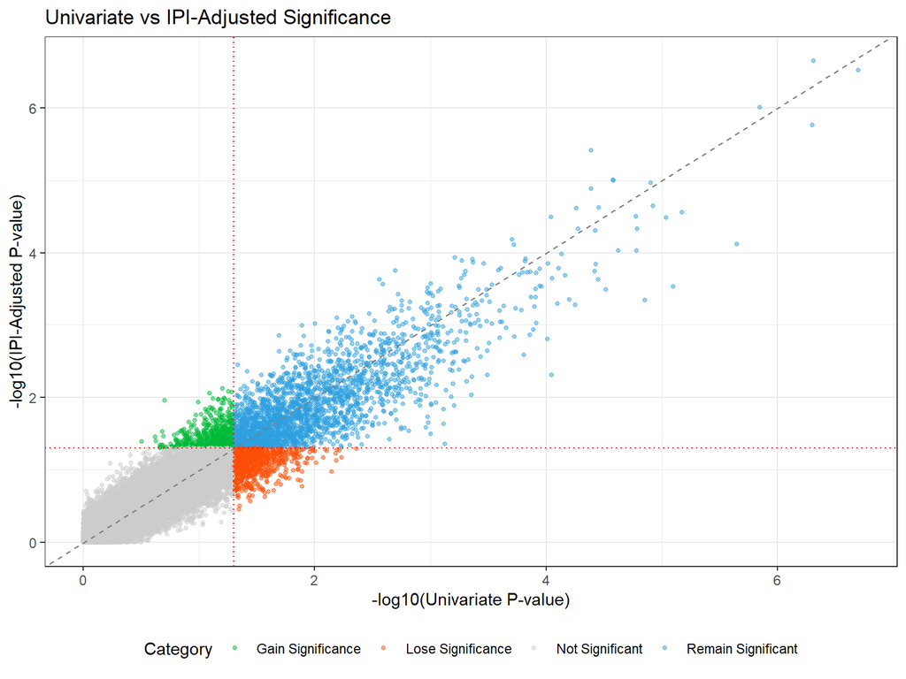

Comparison of Univariate vs IPI-Adjusted Significance

# 6 Summary and Conclusions

## 6.2 Clinical Implications

- Gene expression signatures could **refine risk stratification** beyond IPI
- **T-cell infiltration/function** appears protective across subtypes
- **Proliferation signatures** consistently predict poor outcome
- COO-specific signatures may enable **tailored prognostication**

# 7 Appendix: Subset Comparison

Summary Comparison Across COO Subsets

| Subset | N | FDR < 0.05 | Top Protective Gene | Top Adverse Gene |
| --- | --- | --- | --- | --- |
| Global | 1303 | 6748 | SIRPG | POLR3G |
| GCB | 517 | 909 | CD3D | QPCTL |
| ABC | 345 | 967 | TCF7 | ENPP5 |
| MHG | 164 | 21 | FAM167A | UBE2J2 |
| UNC | 277 | 373 | PCED1B | CDKN2A |

*Analysis performed using R with survival, survminer, dplyr, and enrichR packages.*

*Data source: HMRN/Lacy Cohort (GSE181063)*